# Part 3. 통계분석

### 1. 데이터 샘플링

#### 1. 단순 임의 추출

> sample(x, size, replace=FALSE, prop=NULL)

#### 2. 층화 임의 추출

> **sampling 패키지**

> strata(data, stratanames, size, method)

> getdata(data,m) : 원본 데이터에서 층화 임의 추출 데이터 추출

```r
library(sampling)

data("iris")
str_sample <- strata(iris,'Species', size = c(20,15,15), method = 'srswor')

head(str_sample)
```

```
##    Species ID_unit Prob Stratum
## 6   setosa       6  0.4       1
## 15  setosa      15  0.4       1
## 17  setosa      17  0.4       1
## 21  setosa      21  0.4       1
## 22  setosa      22  0.4       1
## 24  setosa      24  0.4       1
```

```r
head(getdata(iris, str_sample))
```

```
##    Sepal.Length Sepal.Width Petal.Length Petal.Width Species ID_unit Prob
## 6           5.4         3.9          1.7         0.4  setosa       6  0.4
## 15          5.8         4.0          1.2         0.2  setosa      15  0.4
## 17          5.4         3.9          1.3         0.4  setosa      17  0.4
## 21          5.4         3.4          1.7         0.2  setosa      21  0.4
## 22          5.1         3.7          1.5         0.4  setosa      22  0.4
## 24          5.1         3.3          1.7         0.5  setosa      24  0.4
##    Stratum
## 6        1
## 15       1
## 17       1
## 21       1
## 22       1
## 24       1
```

### 2. T-test

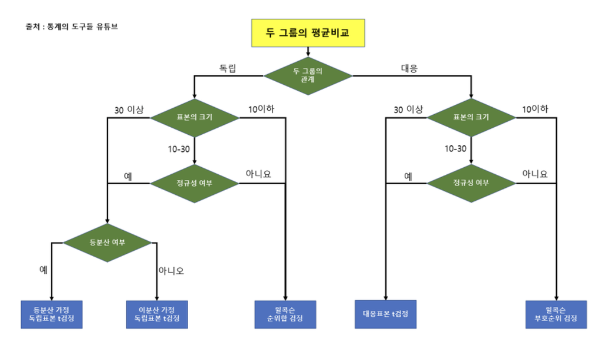

※ 표본 크기 30 이상이면 중심극한정리에 의해 정규성 만족

#### 1. 일표본 T-test

$$H_0 : \mu = \mu_0$$

※ 정규성 검정 후 t-test

- 정규성 검정

※ 표본의 개수가 30개 이상일 때, 중심극한정리에 의해 정규성 가정

> shapiro.test() : 정규성 검정

> ※ 귀무가설 : 데이터가 정규분포를 따른다
- 일표본 t-test
1. 정규 분포를 따를 때, (귀무가설 채택),

> t.test(x, alternative, mu) : t-test
2. 정규 분포를 따르지 않을 때, (귀무가설 기각)

> wilcox.test(x, alternative, mu) : t-test

```r
library(MASS) # for data
data(cats)

# 정규성 검정
#nrow(cats) # n > 30
shapiro.test(cats$Bwt)
```

```
##
##  Shapiro-Wilk normality test
##
## data:  cats$Bwt
## W = 0.95188, p-value = 6.731e-05
```

```r
# t-test
t.test(cats$Bwt, mu=2.6, alternative='two.sided')
```

```
##
##  One Sample t-test
##
## data:  cats$Bwt
## t = 3.0565, df = 143, p-value = 0.002673
## alternative hypothesis: true mean is not equal to 2.6
## 95 percent confidence interval:
##  2.643669 2.803553
## sample estimates:
## mean of x
##  2.723611
```

```r
wilcox.test(cats$Bwt, mu=2.6, alternative='two.sided')
```

```
##
##  Wilcoxon signed rank test with continuity correction
##
## data:  cats$Bwt
## V = 5607, p-value = 0.02532
## alternative hypothesis: true location is not equal to 2.6
```

#### 2. 대응표본 T-test

$$H_0 : \mu_x-\mu_y=D=0$$

※ 두 관측에 대해 정규성 검정 후 t-test

- 대응표본 t-test

> t.test(x,y, alternative, paired, m)
> - paired : TRUE=대응표본 t-test

> wilcox.text(x,y, alternative, paired, m)

```r
df <- data.frame(before = c(7,3,4,5,2,1,6,6,5,4),
                 after = c(8,4,5,6,2,3,6,8,6,5))

# 정규성 검정
shapiro.test(df$before)
```

```
##
##  Shapiro-Wilk normality test
##
## data:  df$before
## W = 0.96446, p-value = 0.8353
```

```r
shapiro.test(df$after)
```

```
##
##  Shapiro-Wilk normality test
##
## data:  df$after
## W = 0.94568, p-value = 0.6178
```

```r
# t.test
t.test(df$before, df$after, paired = TRUE)
```

```
##
##  Paired t-test
##
## data:  df$before and df$after
## t = -4.7434, df = 9, p-value = 0.001054
## alternative hypothesis: true mean difference is not equal to 0
## 95 percent confidence interval:
##  -1.4769046 -0.5230954
## sample estimates:
## mean difference
##              -1
```

#### 3. 독립표본 T-test

$$H_0 : \mu_1 = \mu_2$$

※ 정규성 검정, 등분산 검정 후 t-test  
(정규성 위배 시, 바로 wilcox.test()로)

- 등분산 검정

> var.test()

> ※ 귀무가설 : 두 집단의 분산이 동일하다.
- 독립표본 t-test

> t.test(x,y, alternative, var.equal)
> - var.equal : 등분산성 만족 여부

```r
library(MASS) # for data
data(cats)

# 정규성 검정
#nrow(cats[cats$Sex=='F',])
#nrow(cats[cats$Sex=='M',])
shapiro.test(cats[cats$Sex=='F',]$Bwt)
```

```
##
##  Shapiro-Wilk normality test
##
## data:  cats[cats$Sex == "F", ]$Bwt
## W = 0.89096, p-value = 0.0003754
```

```r
shapiro.test(cats[cats$Sex=='M',]$Bwt)
```

```
##
##  Shapiro-Wilk normality test
##
## data:  cats[cats$Sex == "M", ]$Bwt
## W = 0.97883, p-value = 0.119
```

```r
# 등분산 검정
var.test(Bwt~Sex, data=cats)
```

```
##
##  F test to compare two variances
##
## data:  Bwt by Sex
## F = 0.3435, num df = 46, denom df = 96, p-value = 0.0001157
## alternative hypothesis: true ratio of variances is not equal to 1
## 95 percent confidence interval:
##  0.2126277 0.5803475
## sample estimates:
## ratio of variances
##          0.3435015
```

```r
# t-test
t.test(Bwt~Sex, data = cats, alternative='two.sided', var.equal=FALSE)
```

```
##
##  Welch Two Sample t-test
##
## data:  Bwt by Sex
## t = -8.7095, df = 136.84, p-value = 8.831e-15
## alternative hypothesis: true difference in means between group F and group M is not equal to 0
## 95 percent confidence interval:
##  -0.6631268 -0.4177242
## sample estimates:
## mean in group F mean in group M
##        2.359574        2.900000
```

```r
wilcox.test(Bwt~Sex, data=cats)
```

```
##
##  Wilcoxon rank sum test with continuity correction
##
## data:  Bwt by Sex
## W = 757.5, p-value = 8.201e-11
## alternative hypothesis: true location shift is not equal to 0
```

### 3. 교차분석

#### 1. 적합성 검정

$$H_0 : 실제\ 분포와\ 이론적\ 분포\ 간에\ 차이가\ 없다.$$

> chisq.test(x,y,p)
> - p : 귀무가설을 통해 설정한 확률 값

#### 2. 독립성 검정

$$H_0 : 두\ 변수\ 사이에는\ 연관이\ 없다.\ (독립이다.)$$

> chisq.test( table() )

#### 3. 동질성 검정

$$H_0 : 범주화된\ 집단의\ 분포가\ 서로\ 동일하다.$$

*(독립성 검정과 동일)*

### 4. 분산분석(ANOVA)

#### 1. 일원배치

$$H_0 : k개의\ 집단\ 간\ 모평균에는\
차이가\ 없다.$$

- 분산분석

> aov(formula, data)
- 사후분석

> TukeyHSD(x, conf.level)
> - x : 분산분석 결과

```r
data("iris")

# 분산분석
result_aov <- aov(Sepal.Width ~ Species , data = iris)
summary(result_aov)
```

```
##              Df Sum Sq Mean Sq F value Pr(>F)
## Species       2  11.35   5.672   49.16 <2e-16 ***
## Residuals   147  16.96   0.115
## ---
## Signif. codes:  0 '***' 0.001 '**' 0.01 '*' 0.05 '.' 0.1 ' ' 1
```

```r
# 사후분석
TukeyHSD(result_aov)
```

```
##   Tukey multiple comparisons of means
##     95% family-wise confidence level
##
## Fit: aov(formula = Sepal.Width ~ Species, data = iris)
##
## $Species
##                        diff         lwr        upr     p adj
## versicolor-setosa    -0.658 -0.81885528 -0.4971447 0.0000000
## virginica-setosa     -0.454 -0.61485528 -0.2931447 0.0000000
## virginica-versicolor  0.204  0.04314472  0.3648553 0.0087802
```

#### 2. 이원배치

1. $$H_0 : \alpha_1 = \alpha_2 = \cdots = \alpha_a = 0$$
2. $$H_0 : \beta_1 = \beta_2 = \cdots = \beta_b = 0$$
3. $$H_0 : \alpha_1 \beta_1 + \alpha_2 \beta_2 = \cdots =
   \alpha_{a-1}\beta_{b-1} = 0$$
- 이원배치 분산분석

> aov(formula, data)
> - formula : y~A*B
- 상호작용효과 시각화

> interaction.plot(x.factor, trace.factor, response)
> - x.factor : 요인 A
> - trace.factor : 요인 B
> - response : y

> ※ 두 선이 교차하면 두 독립변수 간 상호작용 존재

```r
data('mtcars')
mtcars$cyl <- as.factor(mtcars$cyl)
mtcars$am <- as.factor(mtcars$am)
car <- mtcars[,c('cyl','am','mpg')]

# 이원배치
car_aov <- aov(mpg~cyl*am, car)
summary(car_aov)
```

```
##             Df Sum Sq Mean Sq F value   Pr(>F)
## cyl          2  824.8   412.4  44.852 3.73e-09 ***
## am           1   36.8    36.8   3.999   0.0561 .
## cyl:am       2   25.4    12.7   1.383   0.2686
## Residuals   26  239.1     9.2
## ---
## Signif. codes:  0 '***' 0.001 '**' 0.01 '*' 0.05 '.' 0.1 ' ' 1
```

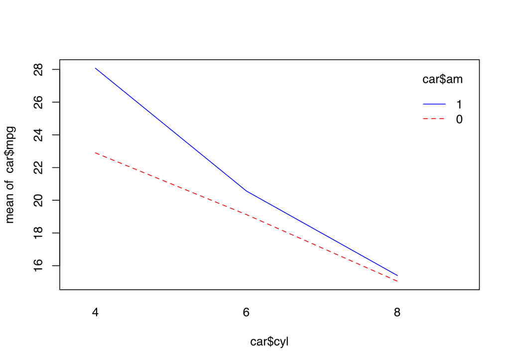

```r
# 시각화
interaction.plot(car$cyl, car$am, car$mpg, col=c('red','blue'))
```

### 5. 상관분석

#### 1. 상관계수에 대한 검정

$$H_0 : \rho = 0$$

- 상관계수

> cor(x,y, method, use)
> - method : 상관계수 방법 (‘pearson’,‘kendall’,‘spearman’)
> - use : na값 처리 방법(‘everything’,‘all.obs’,‘complete.obs’,‘pairwise.complete.obs’)
- 상관계수 행렬 시각화

> pairs(x)

> **corrplot 패키지**

> corrplot(corr, method)
- 상관계수에 대한 검정

> cor.test(x,y, method)

```r
data("iris")

# 상관계수
cor(iris$Petal.Length, iris$Petal.Width)
```

```
## [1] 0.9628654
```

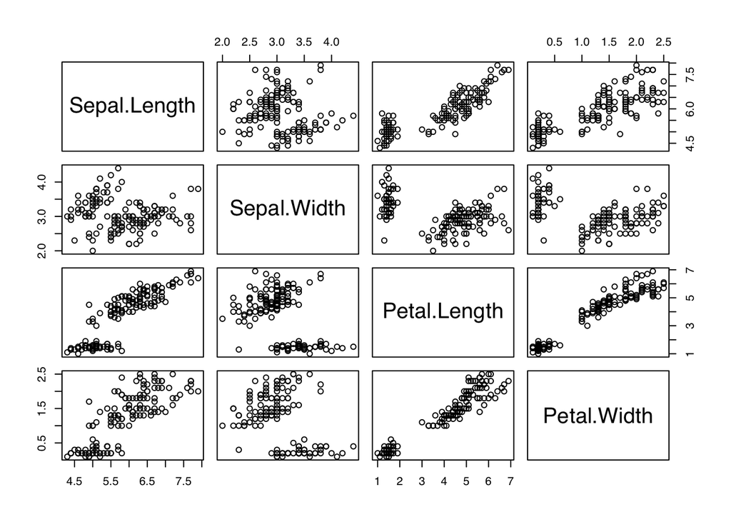

```r
# 시각화
pairs(iris[,1:4])
```

```r
# 가설 검정
cor.test(iris$Petal.Length, iris$Petal.Width)
```

```
##
##  Pearson's product-moment correlation
##
## data:  iris$Petal.Length and iris$Petal.Width
## t = 43.387, df = 148, p-value < 2.2e-16
## alternative hypothesis: true correlation is not equal to 0
## 95 percent confidence interval:
##  0.9490525 0.9729853
## sample estimates:
##       cor
## 0.9628654
```

### 6. 회귀분석

#### 1. 단순/다중 선형회귀분석

- 선형회귀분석

> lm(formula, data)
- 선형회귀모형 진단

> plot(x, which)
> - x : 선형회귀분석 모형
> - which : 그래프 종류

>   1,2 - 오차의 정규성

>   3 - 오차의 정규성 + 이상치

>   4,5 - 이상치
- 예측

> predict(object, newdata)

```r
library(MASS)
data("Cars93")
set.seed(1)
idx <- sample(1:nrow(Cars93),5)
test <- Cars93[idx,]

# 선형회귀분석
Price_lm <- lm(Price ~ EngineSize+RPM+Weight, Cars93)
summary(Price_lm)
```

```
##
## Call:
## lm(formula = Price ~ EngineSize + RPM + Weight, data = Cars93)
##
## Residuals:
##     Min      1Q  Median      3Q     Max
## -10.511  -3.806  -0.300   1.447  35.255
##
## Coefficients:
##               Estimate Std. Error t value Pr(>|t|)
## (Intercept) -51.793292   9.106309  -5.688 1.62e-07 ***
## EngineSize    4.305387   1.324961   3.249  0.00163 **
## RPM           0.007096   0.001363   5.208 1.22e-06 ***
## Weight        0.007271   0.002157   3.372  0.00111 **
## ---
## Signif. codes:  0 '***' 0.001 '**' 0.01 '*' 0.05 '.' 0.1 ' ' 1
##
## Residual standard error: 6.504 on 89 degrees of freedom
## Multiple R-squared:  0.5614, Adjusted R-squared:  0.5467
## F-statistic: 37.98 on 3 and 89 DF,  p-value: 6.746e-16
```

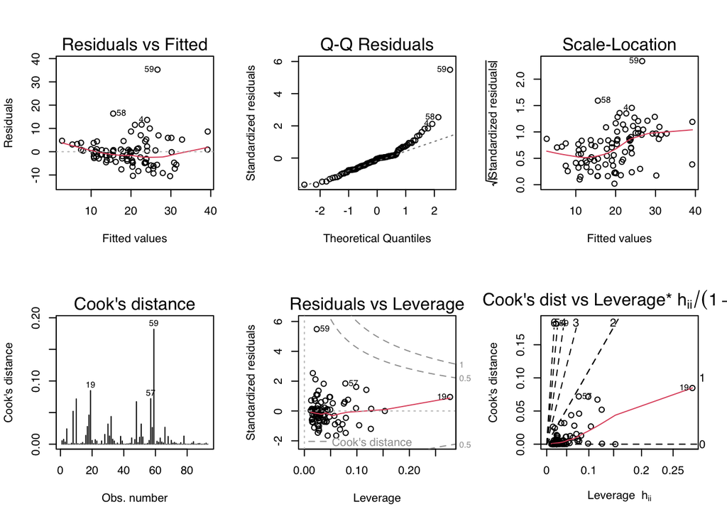

```r
# 모형 진단
par(mfrow=c(2,3))
plot(Price_lm, which=c(1:6))
```

```r
# 예측
predict(Price_lm, test)
```

```
##       68       39        1       34       87
## 21.84678  5.28642 20.33244 11.47548 21.54311
```

#### 2. 최적회귀방정식

- 전진선택법/후진선택법/단계적선택법

> step(object, scope, direction, k)
> - object : 회귀 모형
> - scope : 모형의 범위( list(upper=…, lower=…) )
> - direction : ‘forward’:전진선택법 / ‘backward’=후진제거법 / ‘stepwise’=단계적선택법
> - k : 모형선택기준 (2=AIC / log()=BIC)

```r
library(MASS)
data("Cars93")

# 최적회귀방정식
lm_step <- lm(Price~EngineSize+Horsepower+RPM+Width+Length, Cars93)
step(lm_step, direction = 'backward')
```

```
## Start:  AIC=327.45
## Price ~ EngineSize + Horsepower + RPM + Width + Length
##
##              Df Sum of Sq    RSS    AIC
## - EngineSize  1      0.05 2764.2 325.45
## <none>                    2764.2 327.45
## - RPM         1     65.53 2829.7 327.62
## - Length      1    285.29 3049.4 334.58
## - Width       1    414.88 3179.0 338.45
## - Horsepower  1   1332.75 4096.9 362.04
##
## Step:  AIC=325.45
## Price ~ Horsepower + RPM + Width + Length
##
##              Df Sum of Sq    RSS    AIC
## <none>                    2764.2 325.45
## - RPM         1    120.58 2884.8 327.42
## - Length      1    314.61 3078.8 333.47
## - Width       1    425.45 3189.7 336.76
## - Horsepower  1   2897.11 5661.3 390.12
```

```
##
## Call:
## lm(formula = Price ~ Horsepower + RPM + Width + Length, data = Cars93)
##
## Coefficients:
## (Intercept)   Horsepower          RPM        Width       Length
##   62.001064     0.174981    -0.002843    -1.347265     0.222816
```

#### 3. 다항식 회귀분석

- $$y = \beta_0 + \beta_1(x_1+x_2)+\epsilon$$

> I(x1+x2)
- $$y=\beta_0 + \beta_1 x_1^2+\beta_2 x_2 + \epsilon$$

> I(x1^2)
- $$y=\beta_0 +\beta_1 x + \beta_2 x^2 + \beta_3 x^3 + \cdots + \epsilon$$

> poly(x, degree)

```r
data("quakes")

lm(mag~I(lat+long), data=quakes)
```

```
##
## Call:
## lm(formula = mag ~ I(lat + long), data = quakes)
##
## Coefficients:
##   (Intercept)  I(lat + long)
##       6.71265       -0.01317
```

```r
lm(mag~I(lat^2)+long, data = quakes)
```

```
##
## Call:
## lm(formula = mag ~ I(lat^2) + long, data = quakes)
##
## Coefficients:
## (Intercept)     I(lat^2)         long
##    7.033584     0.000234    -0.014035
```

```r
lm(mag~poly(lat, 3), data=quakes)
```

```
##
## Call:
## lm(formula = mag ~ poly(lat, 3), data = quakes)
##
## Coefficients:
##   (Intercept)  poly(lat, 3)1  poly(lat, 3)2  poly(lat, 3)3
##        4.6204        -0.6424         1.6175         0.3803
```

#### 4. 정규화 회귀분석

- 릿지/라쏘/엘라스틱넷

> **glmnet 패키지**

> glmnet(x,y, alpha , lambda)
> - alpha : 0=릿지 / 1=라쏘 / 0.5=엘라스틱넷
- 교차검증방법을 통한 lambda 설정

> **glmnet 패키지**

> cv.glmnet(x,y alpha)

```r
library(glmnet)
```

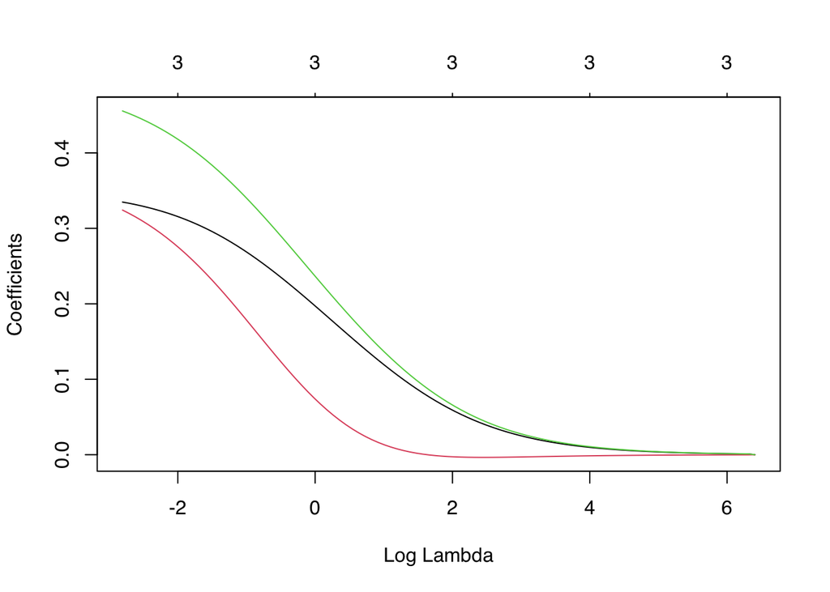

```r
library(MASS) # for data
data("Cars93")

set.seed(1)
train_idx <- sample(1:nrow(Cars93), replace = F, size = nrow(Cars93)*0.7)
train.x <- scale(Cars93[train_idx,c('EngineSize','RPM','Weight')]) # 표준화
test.x <- scale(Cars93[-train_idx,c('EngineSize','RPM','Weight')])
train.y <- scale(Cars93[train_idx,'Price'])
test.y <- scale(Cars93[-train_idx,'Price'])

# 릿지
ridge.lm <- glmnet(train.x,train.y, alpha=0)
plot(ridge.lm, xvar='lambda')
```

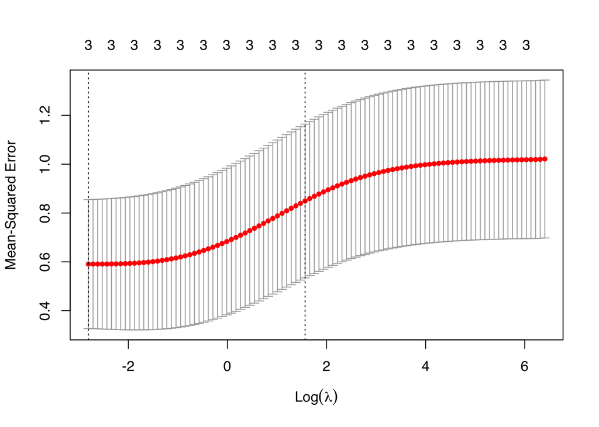

```r
# 교차검증
set.seed(1)
cv.ridge <- cv.glmnet(train.x,train.y,alpha=0)
plot(cv.ridge)
```

```r
# 최적의 lambda
(best_lambda <- cv.ridge$lambda.min)
```

```
## [1] 0.06048311
```

```r
ridge.lm_opt <- glmnet(train.x,train.y, alpha=0, lambda = best_lambda)
```

#### 5. 곡선 데이터

- 곡선 데이터 적합

> **MASS 패키지**

> boxcox(object)
- 로그변환
1. log(y) = x
2. y = log(x)
3. log(y) = log(x)

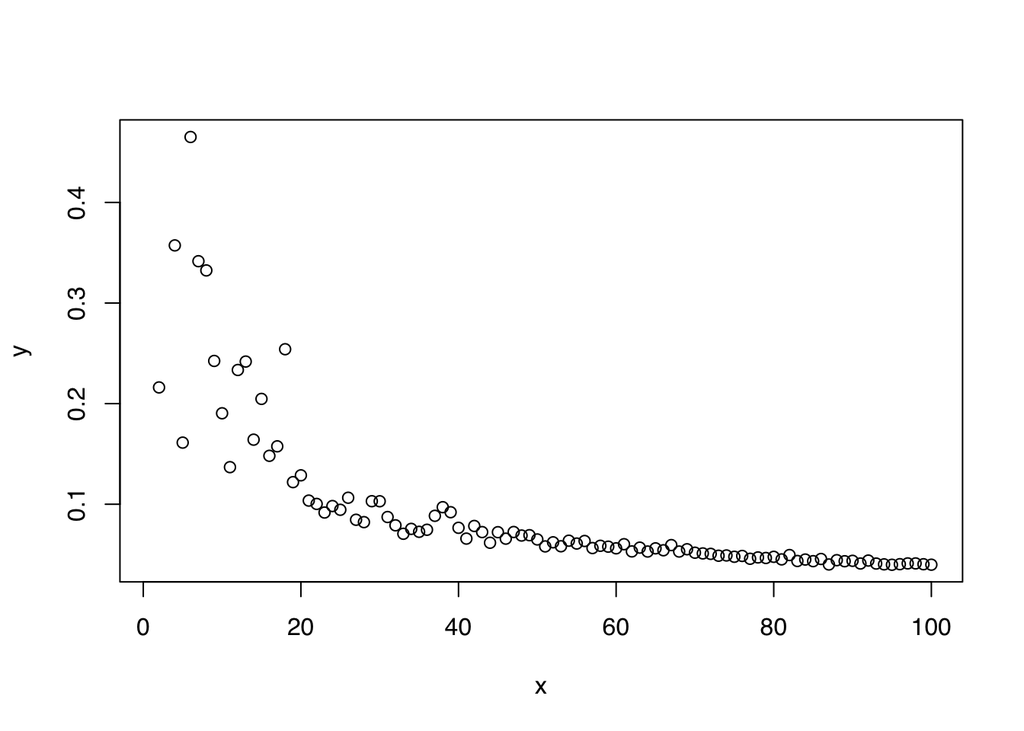

```r
library(MASS)

x <- 1:100
set.seed(5)
norm <- rnorm(100, 0, 5)
y <- (x+norm)^(-.7)
plot(x, y)
```

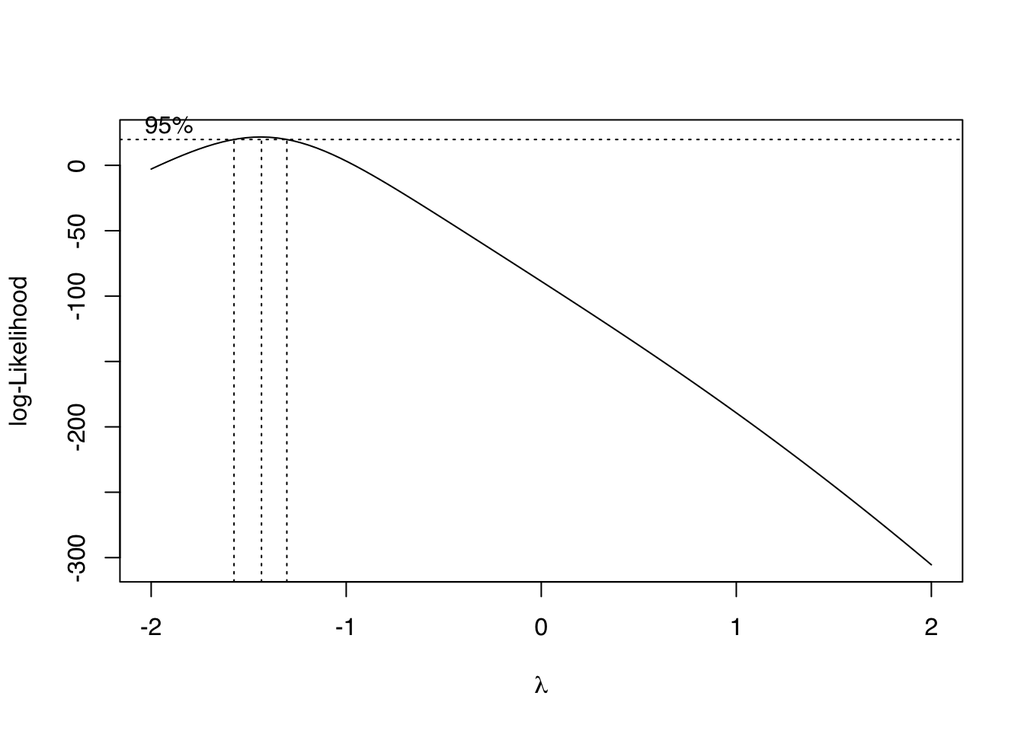

```r
# boxcox
lm_norm <- lm(y~x)
bc_norm <- boxcox(lm_norm)
```

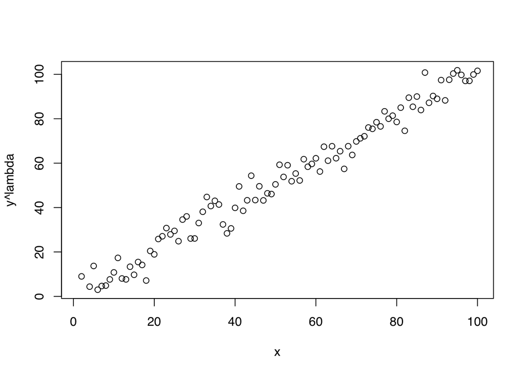

```r
lambda <- bc_norm$x[which.max(bc_norm$y)]

plot(x,y^lambda)
```

#### 6. 일반화 가법모형

$$\hat{y_i}=\hat{\beta_0}+\sum^p_{j=1}f_i(x_{ij}+\hat{\epsilon_i})$$

> **mgcv 패키지**

> gam(formula)
> - formula : y~s(x) (s:분리해서 사용할 예측자)

```r
library(mgcv)
library(MASS) # for data
data("mcycle")

# 일반화 가법모형
gam_model <- gam(accel ~ s(times), data=mcycle)
summary(gam_model)
```

```
##
## Family: gaussian
## Link function: identity
##
## Formula:
## accel ~ s(times)
##
## Parametric coefficients:
##             Estimate Std. Error t value Pr(>|t|)
## (Intercept)  -25.546      1.951   -13.1   <2e-16 ***
## ---
## Signif. codes:  0 '***' 0.001 '**' 0.01 '*' 0.05 '.' 0.1 ' ' 1
##
## Approximate significance of smooth terms:
##            edf Ref.df     F p-value
## s(times) 8.693  8.972 53.52  <2e-16 ***
## ---
## Signif. codes:  0 '***' 0.001 '**' 0.01 '*' 0.05 '.' 0.1 ' ' 1
##
## R-sq.(adj) =  0.783   Deviance explained = 79.8%
## GCV = 545.78  Scale est. = 506       n = 133
```

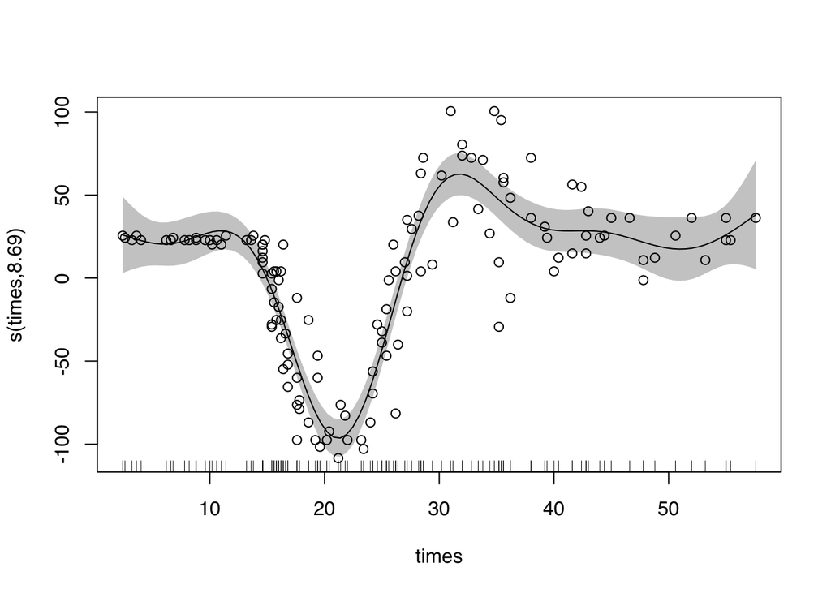

```r
# 시각화
plot(gam_model,residuals = T,pch=1,seWithMean = T,shade=T)
```